# Monthly Sales Project

Luke Austin

2024-03-20

The goal of this project was to use time series analysis skills to fit a model for monthly sales data. Specifically, we will be using a dataset from “sales” in the “astsa” package, and fitting an autoregressive integrated moving averages (ARIMA) model. St will represent the monthly sales data in sales (n = 150).

First, initially examine the data. Plot the data as a time series and view ACF and PACF plots

```r
library(astsa)
```

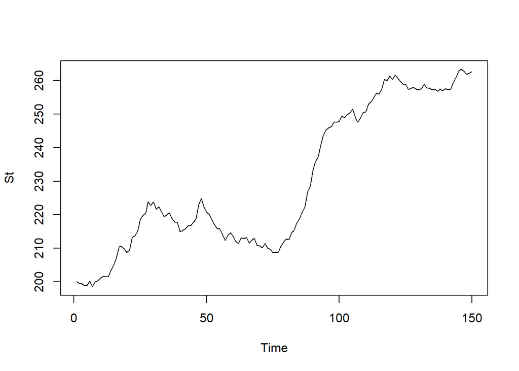

```r
St<- sales
plot.ts(St)
```

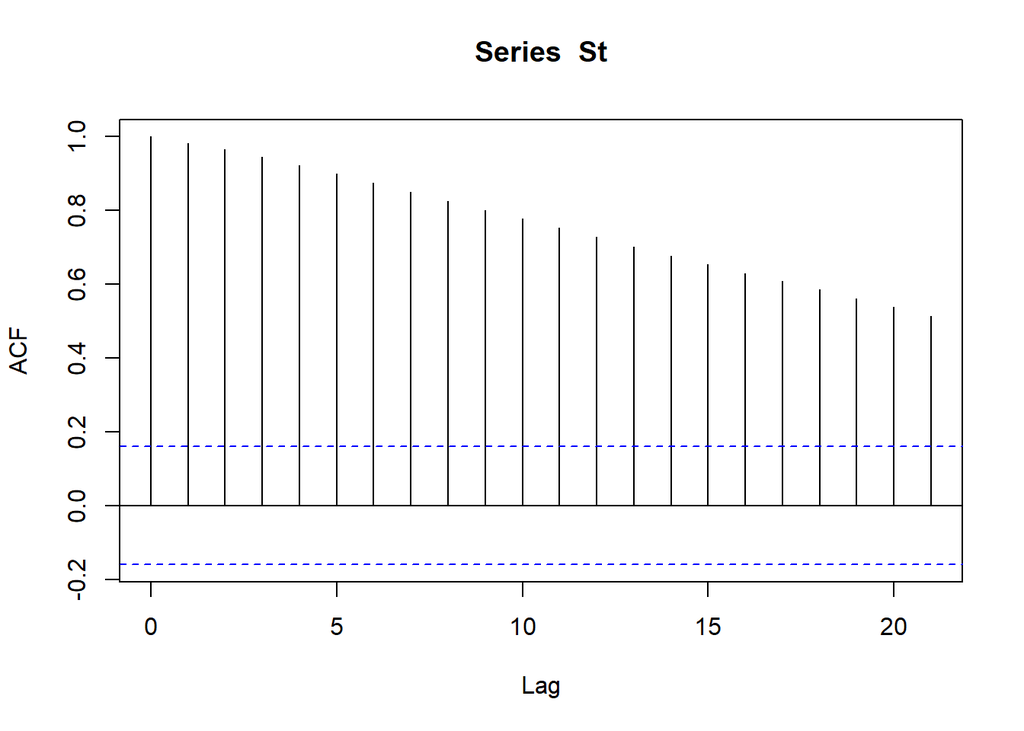

```r
acf(St)
```

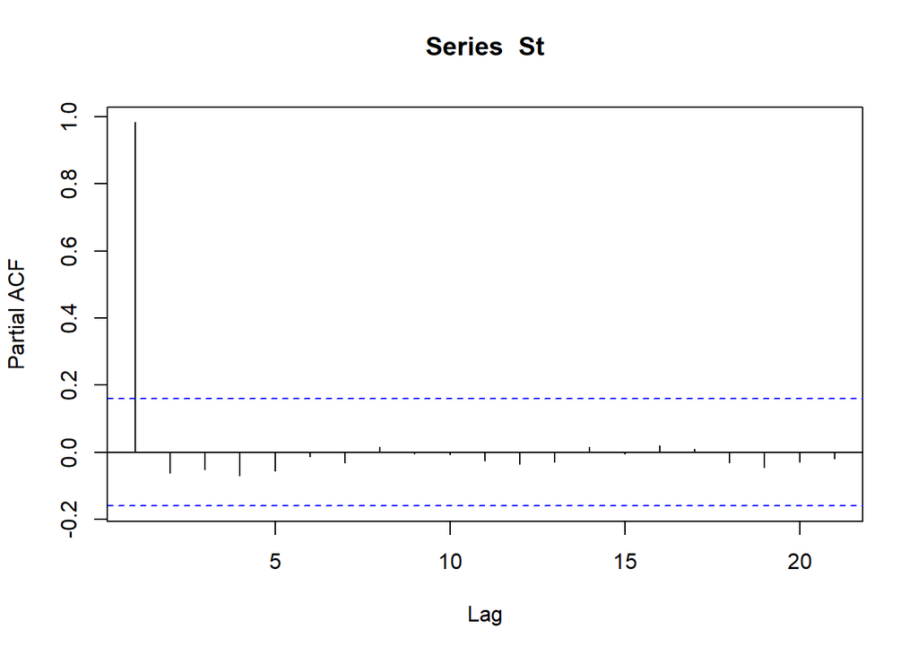

```r
pacf(St)
```

In the time series plot, I noticed an upward trend in the data overtime, and the ACF plot is trailing off very slowly. For this reason, I will transform the data by differencing the data. This creates stationarity

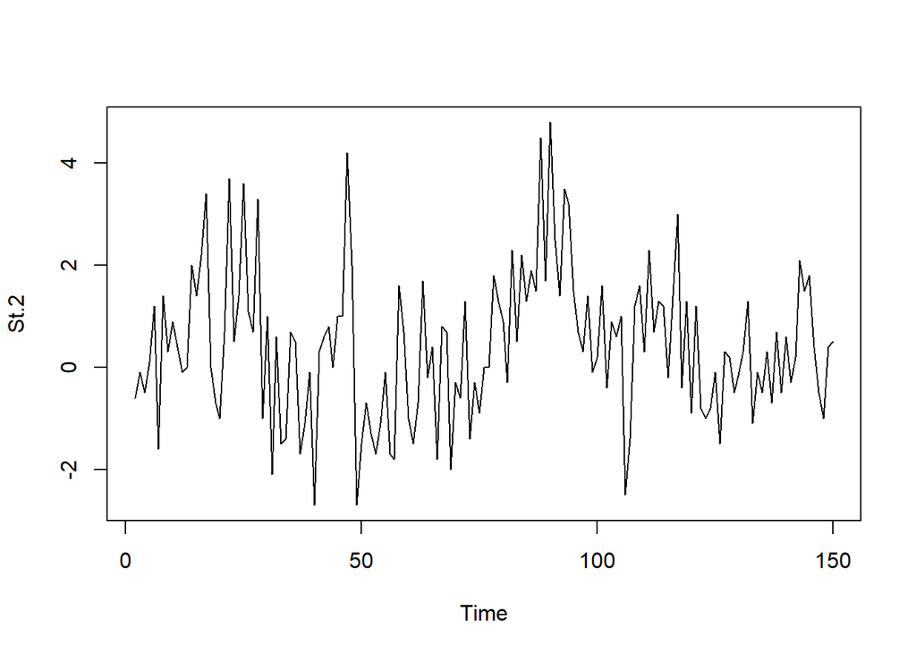

```r
St.2<- diff(St)
plot.ts(St.2)
```

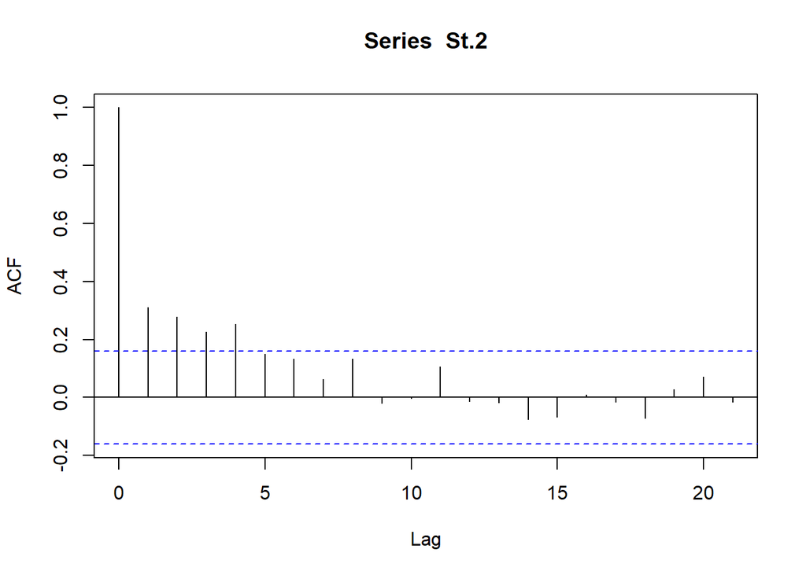

```r
acf(St.2)
```

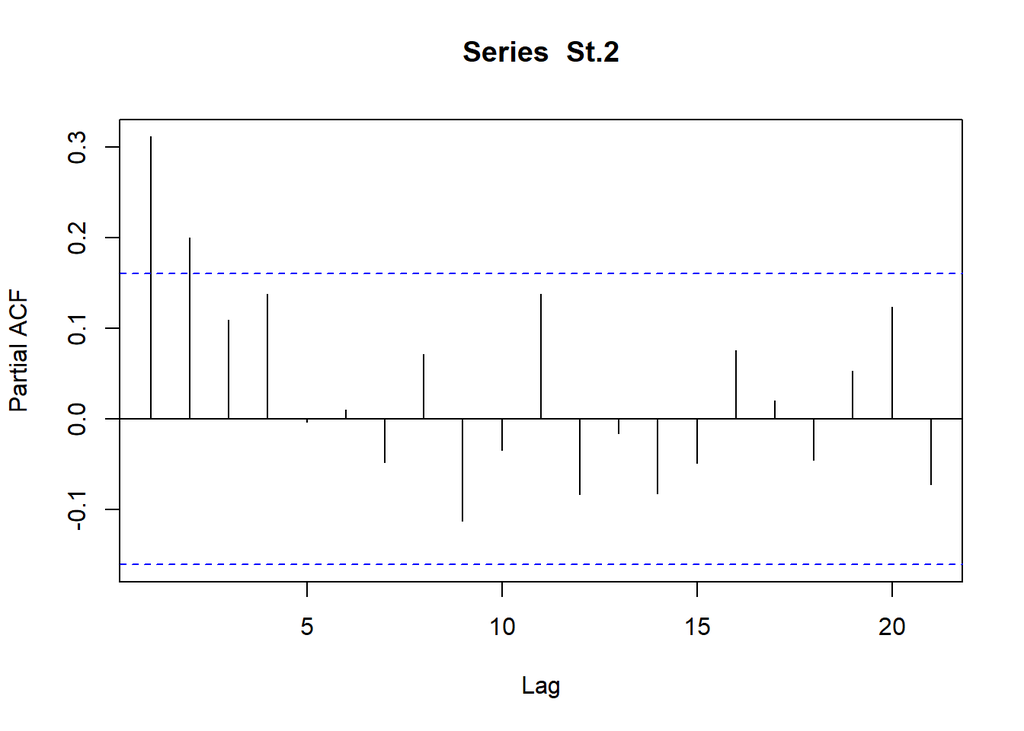

```r
pacf(St.2)
```

This is much better, the data appears stationary and stable now and like something workable in the time series analysis and modeling with going forward.